# Text Analysis in R for Data Analytics | Big Data

Maastricht University

04/10/2020

In this document we show you how to use Natural Language Processing (NLP) for big data text analysis. First we will load some Tweets from Twitter as a Corpus, which is our textual dataset. Before we can analysise it we first need to clean the data, for example, by removing any stop words, such as *the*, or *and*, or *if*. For this we need the packages: **twitterR**, and a text mining package **tm**. The document then shows two quick examples of text analysis techniques for a small sample of *big data*; firstly we create a Wordcloud and secondly we analyse the sentiment that individuals have towards the issue being tweeted about. For this we use two additional packages: **wordcloud** and **syuzhet**, so make sure that you have first installed them for the **R** syntax to run correctly. To plot the sentiment analysis on a graph we have chosen to use the *ggplot2* format, so make sure that this package is already installed.

## Load Data

The first step is to upload the data into the **R** environment. Pay attention to the working directory that you are using. Change working directory if required and load the new packages for twitter and text mining.

```r
library(twitteR)
library(tm)
```

Loading Text Data: Create corpus database

```r
tweets.text <- readChar("greenbonds.txt", nchars=file.info("greenbonds.txt")$size)
tweets.text.corpus <- Corpus(VectorSource(tweets.text))
```

Text Cleaning: remove stop words

```r
tweets.text.corpus <- tm_map(tweets.text.corpus,
function(x)removeWords(x,stopwords()))
```

## Wordcloud

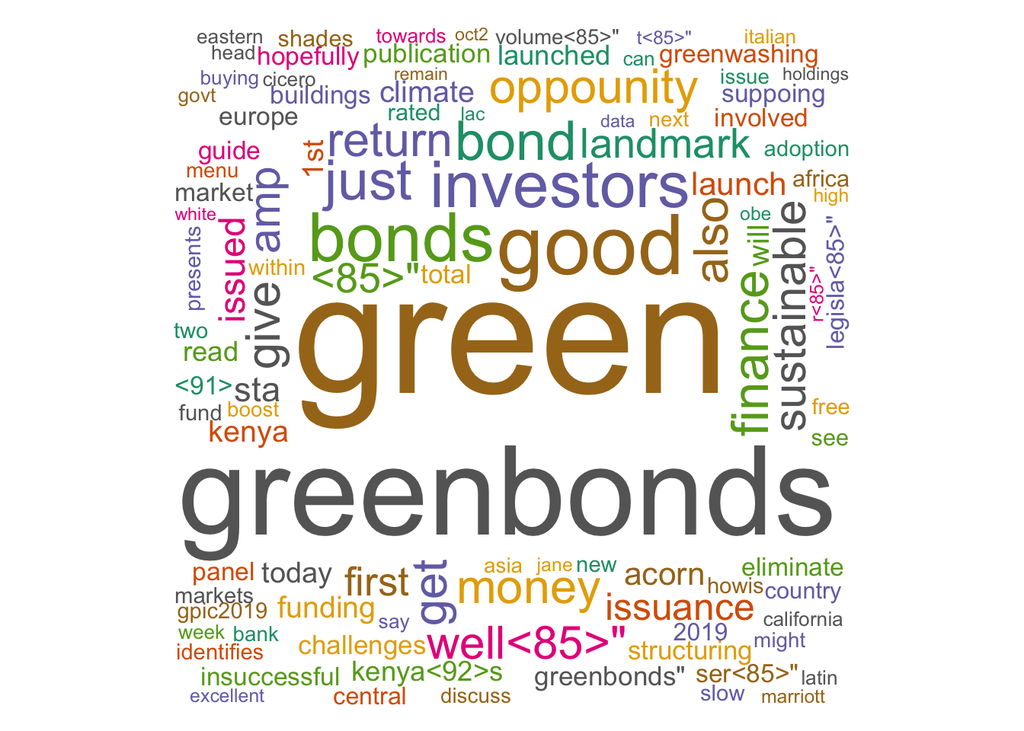

```r
library("wordcloud")
wordcloud(tweets.text.corpus,min.freq = 2, scale=c(7,0.5),
colors=brewer.pal(8, "Dark2"),
random.color= TRUE, random.order = FALSE, max.words = 150)
```

# Sentiment Analysis

The sentiment analysis is conducted to create a visualization. Here we need to transpose the data to a dataframe and compute the column sum across the rows for each type of grouping variable.

```r
library(syuzhet)
tweets.text <- iconv(tweets.text,"WINDOWS-1252","UTF-8") #International keyboards
sentiment <- get_nrc_sentiment(tweets.text)
sentiment_df <- data.frame(t(sentiment))
sentiment_df1 <- data.frame(rowSums(sentiment_df))

# name rows and columns of the dataframe
names(sentiment_df1)[1] <- "count"
sentiment_df1 <- cbind("sentiment" = rownames(sentiment_df1),
sentiment_df1)
rownames(sentiment_df1) <- NULL
```

Plot the distinct emotions:

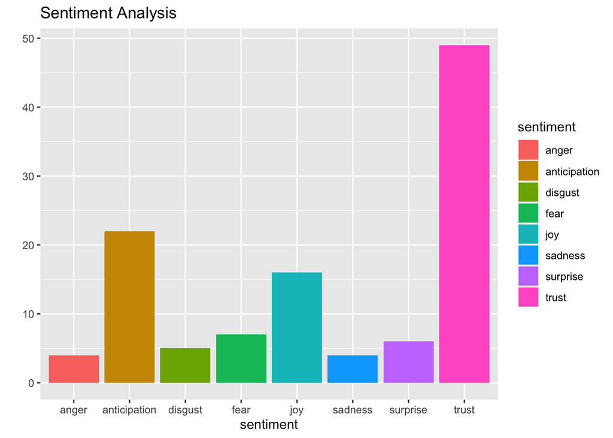

```r
library(ggplot2)
qplot(sentiment, data=sentiment_df1[1:8,], weight=count,
geom="bar",fill=sentiment)+ggtitle("Sentiment Analysis")
```

To plot only the positive and negative emotions, which are the final two rows:

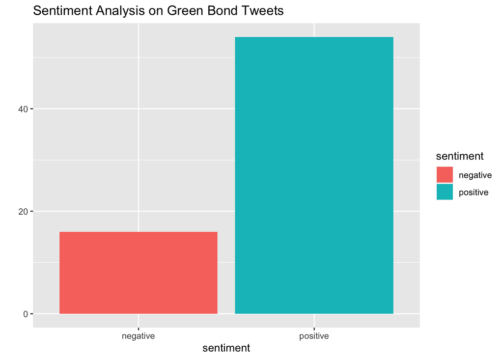

```r
qplot(sentiment, data=sentiment_df1[9:10,], weight=count,
geom="bar",fill=sentiment)+ggtitle("Sentiment Analysis on Green Bond Tweets")
```